# NESE Post-Breeding females: foraging strategies from behaviour and their isotopic niches

Luis Huckstadt

2026-11-11

# 1 Overview

A self-contained analysis, built from scratch, in two parts.

**Part A — Identify foraging strategies from behaviour.** Movement and diving variables only (19 variables). PCA → number of dimensions chosen by parallel analysis → HCPC (Ward + k-means consolidation). The number of strategies is chosen with explicit, data-driven rules: the gap statistic, a minimum cluster size, and bootstrap stability. Every choice is followed by a sensitivity check.

**Part B — Isotopic niches of those strategies.** Stable isotopes are **not** used in Part A, so they are an independent test of whether behaviourally defined strategies also differ in diet / foraging habitat: permutation tests, effect sizes, equivalence tests and Bayesian niche size and overlap (nicheROVER, SEA).

All random steps are seeded. For a first test run, lower `N_BOOT`, `N_PERM`, `N_PA` and `N_POST` in the settings chunk.

```r
library(dplyr)
library(tidyr)
library(ggplot2)
library(FactoMineR)
library(factoextra)
library(cluster)     # clusGap, silhouette
# mclust is called as mclust::adjustedRandIndex (attaching it masks dplyr::count)
library(nicheROVER)
# MASS is called as MASS:: to avoid masking dplyr::select
```

# 2 Settings

```r
SEED <- 20261102
set.seed(SEED)

# Part A
N_DIM_OVERRIDE  <- NULL   # NULL = use parallel analysis; or set a number
# K = 3 rather than the 1-SE gap choice of 2: gap(3) > gap(2) but within 1 SE, so
# the gap statistic does not discriminate between them; k = 3 has the highest
# silhouette among admissible solutions, all three strategies are stable, k = 3 is a
# nested refinement of k = 2, and the split-off group differs in variables NOT used
# for clustering (trip duration, mass gain, isotopes). See "Choosing between k = 2 and k = 3".
K_OVERRIDE      <- 3      # NULL = use the decision rule below; or set a number
K_RANGE         <- 2:8    # candidate numbers of strategies
MIN_CLUSTER_N   <- 5      # smallest acceptable strategy (individuals)
MIN_JACCARD     <- 0.75   # every strategy must be at least "stable" (Hennig 2007)
N_PA            <- 1000   # parallel-analysis permutations
N_GAP           <- 200    # gap-statistic reference data sets
N_BOOT          <- 500    # bootstrap replicates for stability
SKEW_THRESHOLD  <- 1      # |skewness| above which variables are log-transformed in the sensitivity run
N_NULL          <- 500    # simulations for the "is there cluster structure?" test

# Part B
N_PERM          <- 4999   # permutations for Freedman-Lane tests
N_POST          <- 1e4    # nicheROVER posterior draws
LOW_CONFIDENCE  <- 0.80   # seals with bootstrap co-assignment below this are "low confidence"

# SIBER (needs JAGS installed: https://mcmc-jags.sourceforge.io, then install.packages(c("rjags", "SIBER")))
SIBER_PARMS  <- list(n.iter = 2e4, n.burnin = 1e3, n.thin = 10, n.chains = 2)
SIBER_PRIORS <- list(R = 1 * diag(2), k = 2, tau.mu = 1.0E-3)   # SIBER defaults
SIBER_DRAWS  <- 500      # posterior draws used for Bayesian ellipse overlap
SIBER_P      <- 0.95     # ellipse used for overlap (0.95 = 95% ellipse; NULL = standard ellipse)
HAS_SIBER <- requireNamespace("SIBER", quietly = TRUE) && requireNamespace("rjags", quietly = TRUE)
if (!HAS_SIBER) message("SIBER/rjags (JAGS) not available: the SIBER section will be skipped.")
# Equivalence margins (permil): differences smaller than these are considered
# ecologically negligible. Biological judgement - justify in the paper.
EQUIV <- c(d13C = 0.3, d15N = 1.0)

OUT <- "../results/PB_strategies"
FIG <- "../figures/PB_strategies"
dir.create(OUT, recursive = TRUE, showWarnings = FALSE)
dir.create(FIG, recursive = TRUE, showWarnings = FALSE)

PAL <- c("#1b9e77", "#d95f02", "#7570b3", "#e7298a", "#66a61e", "#e6ab02", "#a6761d", "#666666")
```

# 3 Data

```r
SPACE <- c("MaxLat_degrees", "MinLon_degrees",
           "MedianDistToContShelf_km", "SdDistContShelf_km",
           "MesoEcoProportionShelf", "MesoEcoProportionCAC",
           "MesoEcoProportionSubArcticPac", "MesoEcoProportionNorthCPac")
DIVE  <- c("Mean_Depth_m", "Mean_Depth_sd", "Mean_Duration_sec", "Mean_Duration_sd",
           "Pct_TransitDives", "Pct_ForagingDives", "Pct_DriftDives", "Pct_BenthicDives",
           "PctTripDiving", "DeepDayForageDivesMedian_m", "DeepNightForageDivesMedian_m")
BEHAV <- c(SPACE, DIVE)
ISO   <- c("d13C", "d15N")
REGIONS <- c(MesoEcoProportionShelf        = "Shelf",
             MesoEcoProportionCAC          = "California Current",
             MesoEcoProportionSubArcticPac = "Subarctic",
             MesoEcoProportionNorthCPac    = "North Central Pacific")
```

```r
meta <- read.csv("../data/IsotopesDatasetForLuis_2023_4_4.csv") %>%
  transmute(TOPPID = as.character(TOPPID), MainID = as.character(MainID),
            TripDuration_days, MassGainRate_kgPerDay_Dcrocker) %>%
  distinct(TOPPID, .keep_all = TRUE)

dat <- readRDS("../data/f.PCAdata.1.rds") %>%
  mutate(TOPPID = as.character(TOPPID)) %>%
  filter(Trip == "PostBreeding") %>%
  left_join(meta, by = "TOPPID") %>%
  mutate(ProcedureYear = factor(ProcedureYear)) %>%
  as.data.frame()
rownames(dat) <- dat$TOPPID

stopifnot(all(c(BEHAV, ISO) %in% names(dat)), !anyDuplicated(dat$TOPPID))
cat("Rows with missing behavioural data:", sum(!complete.cases(dat[BEHAV])), "\n")
```

```
## Rows with missing behavioural data: 0
```

```r
dat <- dat[complete.cases(dat[BEHAV]), ]
n <- nrow(dat)
cat(n, "Post-Breeding trips from", n_distinct(dat$MainID, na.rm = TRUE), "seals\n")
```

```
## 93 Post-Breeding trips from 87 seals
```

```r
table(dat$ProcedureYear)
```

```
##
## 2009 2010 2011 2012 2013 2014
##   15   13   18   17   14   16
```

The unit of analysis is the **trip**. Seals tracked in more than one year contribute more than one trip; this is checked in the sensitivity analyses (one trip per seal).

```r
dat %>% filter(!is.na(MainID)) %>% dplyr::count(MainID) %>% filter(n > 1)
```

```
##   MainID n
## 1   M778 2
## 2   M780 2
## 3   N796 2
## 4   R148 2
## 5   R541 2
## 6   S126 2
```

## 3.1 Data checks

```r
# 1. Mesoecoregion proportions are compositional (they sum to 1), so one of the
#    four is redundant. PCA handles the exact linear dependence (one zero eigenvalue).
summary(rowSums(dat[names(REGIONS)]))
```

```
##    Min. 1st Qu.  Median    Mean 3rd Qu.    Max.
##       1       1       1       1       1       1
```

```r
# 2. Dive-type percentages: check their definition if they do not sum to ~100
summary(rowSums(dat[c("Pct_TransitDives", "Pct_ForagingDives",
                      "Pct_DriftDives", "Pct_BenthicDives")]))
```

```
##    Min. 1st Qu.  Median    Mean 3rd Qu.    Max.
##   34.06   94.01   96.19   93.93   97.39   99.18
```

```r
# 3. Skewness (PCA and Ward are least-squares methods, sensitive to long tails)
skew <- function(x) { z <- (x - mean(x)) / sd(x); mean(z^3) }
sort(round(sapply(dat[BEHAV], skew), 2))
```

```
##                  Mean_Depth_m             Pct_ForagingDives
##                         -1.28                         -0.37
##                 PctTripDiving MesoEcoProportionSubArcticPac
##                         -0.14                         -0.08
##                MinLon_degrees            SdDistContShelf_km
##                         -0.05                          0.01
##      MedianDistToContShelf_km              Pct_TransitDives
##                          0.02                          0.12
##                MaxLat_degrees    MesoEcoProportionNorthCPac
##                          0.24                          0.57
##    DeepDayForageDivesMedian_m                Pct_DriftDives
##                          0.60                          1.20
##              Mean_Duration_sd                 Mean_Depth_sd
##                          1.58                          1.65
##             Mean_Duration_sec  DeepNightForageDivesMedian_m
##                          1.69                          1.87
##          MesoEcoProportionCAC              Pct_BenthicDives
##                          2.10                          4.69
##        MesoEcoProportionShelf
##                          8.15
```

```r
# 4. Strongly redundant pairs (|Spearman rho| > 0.85) give extra weight to one axis
rho <- cor(dat[BEHAV], method = "spearman"); rho[upper.tri(rho, diag = TRUE)] <- NA
as.data.frame(as.table(rho)) %>% filter(abs(Freq) > 0.85) %>% arrange(desc(abs(Freq)))
```

```
##                            Var1                     Var2       Freq
## 1            SdDistContShelf_km MedianDistToContShelf_km  0.9512996
## 2 MesoEcoProportionSubArcticPac           MaxLat_degrees  0.9432758
## 3    MesoEcoProportionNorthCPac       SdDistContShelf_km  0.9066012
## 4      MedianDistToContShelf_km           MinLon_degrees -0.8899913
## 5    MesoEcoProportionNorthCPac MedianDistToContShelf_km  0.8814287
```

# 4 Part A — Foraging strategies from behaviour

## 4.1 Helper functions

```r
pc_scores <- function(X, nd) prcomp(X, center = TRUE, scale. = TRUE)$x[, 1:nd, drop = FALSE]

# Ward + k-means consolidation from the Ward centroids (= FactoMineR::HCPC),
# fast enough for bootstrap loops
hcpc_lite <- function(S, k) {
  cl  <- cutree(hclust(dist(S), method = "ward.D2"), k)
  cen <- apply(S, 2, function(x) tapply(x, cl, mean))
  tryCatch(kmeans(S, centers = cen, iter.max = 100)$cluster,
           error = function(e) cl)   # if consolidation empties a cluster, keep Ward
}

# HCPC's own rule for suggesting k: minimise W(k)/W(k-1)
hcpc_ratio <- function(S, ks) {
  h <- hclust(dist(S), method = "ward.D2")
  g <- sort(h$height^2 / (2 * nrow(S)), decreasing = TRUE)
  W <- sapply(1:(max(ks) + 1), function(k) sum(g[k:length(g)]))
  setNames(W[ks] / W[ks - 1], ks)
}

# Whole-pipeline bootstrap: resample seals, redo PCA + clustering.
# Returns mean Jaccard per cluster and, per seal, the proportion of resamples in
# which it stays with its full-data cluster mates (co-assignment).
boot_stability <- function(X, nd, k, B = N_BOOT) {
  ref <- hcpc_lite(pc_scores(X, nd), k); m <- nrow(X)
  J <- matrix(NA, B, k)
  co <- seen <- numeric(m)
  for (b in 1:B) {
    ix <- unique(sample(m, replace = TRUE))
    cb <- hcpc_lite(pc_scores(X[ix, , drop = FALSE], nd), k)
    for (cc in 1:k) {
      A <- ix[ref[ix] == cc]
      if (length(A)) J[b, cc] <- max(sapply(unique(cb), function(j) {
        Bj <- ix[cb == j]; length(intersect(A, Bj)) / length(union(A, Bj)) }))
    }
    lab <- setNames(cb, ix)
    for (i in ix) {
      mates <- setdiff(ix[ref[ix] == ref[i]], i)
      if (length(mates)) {
        co[i] <- co[i] + mean(lab[as.character(mates)] == lab[as.character(i)])
        seen[i] <- seen[i] + 1
      }
    }
  }
  list(ref = ref, jaccard = colMeans(J, na.rm = TRUE), coassign = co / pmax(seen, 1))
}
```

## 4.2 PCA and number of dimensions

The number of dimensions is chosen by **Horn’s parallel analysis**: keep a dimension only if its eigenvalue exceeds the 95th percentile of eigenvalues from data with the same variables but no correlation among them (each column permuted independently). Kaiser, cumulative variance and broken stick are shown for comparison.

```r
X <- dat[BEHAV]
res.pca.full <- PCA(X, ncp = 10, graph = FALSE)
# Eigenvalues of the correlation matrix (identical to FactoMineR's standardised PCA)
eig <- pmax(eigen(cor(X), symmetric = TRUE, only.values = TRUE)$values, 0)
p <- length(eig)

pa <- apply(replicate(N_PA, eigen(cor(apply(X, 2, sample)), symmetric = TRUE,
                                  only.values = TRUE)$values), 1, quantile, 0.95)
bs <- sapply(1:p, function(k) sum(1 / (k:p)))

pc_tab <- data.frame(dim = 1:p, eigenvalue = eig, pct_var = 100 * eig / sum(eig),
                     cum_pct = 100 * cumsum(eig) / sum(eig), parallel_95 = pa, broken_stick = bs)
round(head(pc_tab, 10), 3)
```

```
##    dim eigenvalue pct_var cum_pct parallel_95 broken_stick
## 1    1      6.418  33.781  33.781       2.088        3.548
## 2    2      3.343  17.593  51.374       1.837        2.548
## 3    3      2.504  13.178  64.552       1.670        2.048
## 4    4      1.892   9.956  74.507       1.549        1.714
## 5    5      1.214   6.391  80.898       1.428        1.464
## 6    6      0.879   4.624  85.522       1.330        1.264
## 7    7      0.713   3.752  89.274       1.242        1.098
## 8    8      0.569   2.996  92.270       1.151        0.955
## 9    9      0.355   1.868  94.138       1.073        0.830
## 10  10      0.286   1.507  95.645       1.007        0.719
```

```r
rules <- c(`Parallel analysis (95%)` = which(eig <= pa)[1] - 1,
           `Broken stick`            = which(eig <= bs)[1] - 1,
           `Kaiser (eigenvalue > 1)` = sum(eig > 1),
           `Cumulative >= 75%`       = which(pc_tab$cum_pct >= 75)[1])
rules
```

```
## Parallel analysis (95%)            Broken stick Kaiser (eigenvalue > 1)
##                       4                       4                       5
##       Cumulative >= 75%
##                       5
```

```r
N_DIM <- if (is.null(N_DIM_OVERRIDE)) max(2, rules[["Parallel analysis (95%)"]]) else N_DIM_OVERRIDE
cat("Dimensions retained: N_DIM =", N_DIM, "(", round(pc_tab$cum_pct[N_DIM], 1), "% of variance )\n")
```

```
## Dimensions retained: N_DIM = 4 ( 74.5 % of variance )
```

```r
write.csv(pc_tab, file.path(OUT, "A_pca_dimensions.csv"), row.names = FALSE)
```

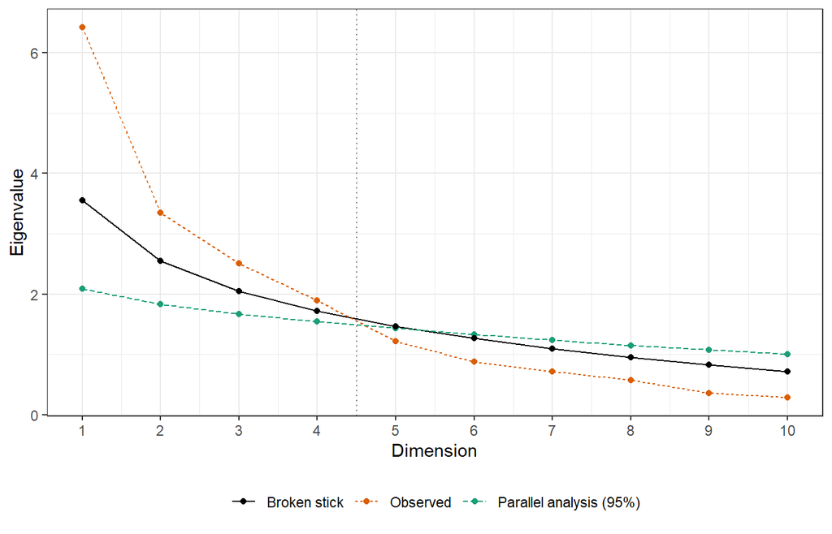

```r
g <- pc_tab %>% filter(dim <= 10) %>%
  pivot_longer(c(eigenvalue, parallel_95, broken_stick)) %>%
  mutate(name = recode(name, eigenvalue = "Observed", parallel_95 = "Parallel analysis (95%)",
                       broken_stick = "Broken stick")) %>%
  ggplot(aes(dim, value, colour = name, linetype = name)) + geom_line() + geom_point() +
  geom_vline(xintercept = N_DIM + 0.5, colour = "grey50", linetype = 3) +
  scale_x_continuous(breaks = 1:10) +
  scale_colour_manual(values = c("black", "#d95f02", "#1b9e77")) +
  labs(x = "Dimension", y = "Eigenvalue", colour = NULL, linetype = NULL) +
  theme_bw() + theme(legend.position = "bottom")
g
```

```r
ggsave(file.path(FIG, "A_pca_dimensions.pdf"), g, width = 7, height = 4.5)
```

### 4.2.1 What the dimensions represent

Correlations between variables and dimensions (unrotated; these are the axes used for clustering). Only the first two axes are usually stable enough to be interpreted one by one — describe strategies with the original variables (below) rather than by individual dimensions.

```r
round(res.pca.full$var$cor[, 1:N_DIM], 2)
```

```
##                               Dim.1 Dim.2 Dim.3 Dim.4
## MaxLat_degrees                 0.59 -0.36 -0.57  0.18
## MinLon_degrees                 0.78  0.33 -0.06 -0.14
## MedianDistToContShelf_km      -0.93 -0.10  0.20  0.04
## SdDistContShelf_km            -0.94 -0.04  0.22  0.01
## MesoEcoProportionShelf         0.39 -0.06  0.65 -0.17
## MesoEcoProportionCAC           0.44  0.64  0.17 -0.14
## MesoEcoProportionSubArcticPac  0.59 -0.40 -0.61  0.13
## MesoEcoProportionNorthCPac    -0.88  0.02  0.35 -0.01
## Mean_Depth_m                  -0.74  0.32 -0.41  0.08
## Mean_Depth_sd                 -0.17  0.03  0.30  0.78
## Mean_Duration_sec              0.03  0.88 -0.01  0.30
## Mean_Duration_sd               0.26  0.61 -0.11  0.48
## Pct_TransitDives              -0.16 -0.62 -0.17  0.48
## Pct_ForagingDives             -0.38  0.41 -0.35 -0.54
## Pct_DriftDives                 0.46  0.03  0.30  0.50
## Pct_BenthicDives               0.53  0.15  0.55  0.01
## PctTripDiving                  0.23  0.72 -0.18  0.07
## DeepDayForageDivesMedian_m     0.83 -0.21  0.15 -0.22
## DeepNightForageDivesMedian_m   0.44 -0.33  0.53 -0.12
```

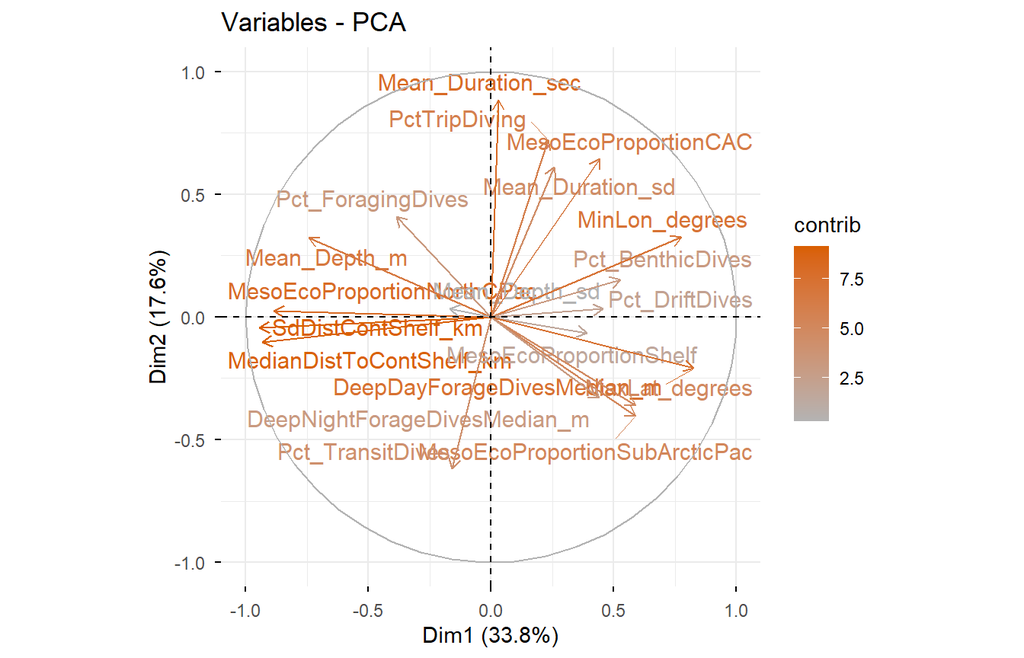

```r
fviz_pca_var(res.pca.full, repel = TRUE, col.var = "contrib",
             gradient.cols = c("grey70", "#d95f02"))
```

## 4.3 Number of strategies

Candidate solutions k = 2–8 are compared with:

- **Gap statistic** (Tibshirani et al. 2001, 1-SE rule): compares within-cluster dispersion with that of structureless reference data.
- **HCPC’s own rule** (minimum within-inertia ratio), shown for information.
- **Mean silhouette** and **minimum cluster size**.
- **Bootstrap stability**: mean Jaccard similarity of each cluster across 500 resamples of the whole pipeline.

**Decision rule.** Take the k suggested by the gap statistic, provided every strategy has ≥ `MIN_CLUSTER_N` seals and a mean Jaccard ≥ `MIN_JACCARD`. Otherwise take the largest k below it that meets both conditions.

```r
S <- res.pca.full$ind$coord[, 1:N_DIM]

gs <- clusGap(S, FUNcluster = function(x, k) list(cluster = hcpc_lite(x, k)),
              K.max = max(K_RANGE), B = N_GAP, spaceH0 = "scaledPCA", verbose = FALSE)
k_gap <- maxSE(gs$Tab[, "gap"], gs$Tab[, "SE.sim"], method = "Tibs2001SEmax")
hr <- hcpc_ratio(S, K_RANGE)

stab <- lapply(K_RANGE, function(k) { set.seed(SEED); boot_stability(X, N_DIM, k) })
names(stab) <- K_RANGE

k_tab <- data.frame(
  k = K_RANGE,
  gap = gs$Tab[K_RANGE, "gap"], gap_se = gs$Tab[K_RANGE, "SE.sim"],
  hcpc_ratio = hr,
  silhouette = sapply(K_RANGE, function(k) mean(silhouette(hcpc_lite(S, k), dist(S))[, 3])),
  sizes = sapply(stab, function(s) paste(sort(table(s$ref), decreasing = TRUE), collapse = "/")),
  min_size = sapply(stab, function(s) min(table(s$ref))),
  min_jaccard = sapply(stab, function(s) min(s$jaccard)),
  row.names = NULL)
k_tab$passes <- k_tab$min_size >= MIN_CLUSTER_N & k_tab$min_jaccard >= MIN_JACCARD
k_tab %>% mutate(across(where(is.double), ~ round(.x, 3)))
```

```
##   k   gap gap_se hcpc_ratio silhouette              sizes min_size min_jaccard
## 1 2 0.697  0.026      0.665      0.367              53/40       40       0.997
## 2 3 0.711  0.027      0.757      0.406            48/39/6        6       0.850
## 3 4 0.673  0.026      0.822      0.415          48/39/5/1        1       0.841
## 4 5 0.685  0.025      0.826      0.311       37/26/24/5/1        1       0.581
## 5 6 0.686  0.026      0.878      0.263    36/22/17/12/5/1        1       0.414
## 6 7 0.716  0.026      0.881      0.253 27/22/15/12/11/5/1        1       0.472
## 7 8 0.713  0.027      0.886      0.265 25/22/16/9/8/7/5/1        1       0.387
##   passes
## 1   TRUE
## 2   TRUE
## 3  FALSE
## 4  FALSE
## 5  FALSE
## 6  FALSE
## 7  FALSE
```

```r
write.csv(k_tab, file.path(OUT, "A_number_of_strategies.csv"), row.names = FALSE)

ok <- k_tab$k[k_tab$passes]
K_SUGGESTED <- if (k_gap %in% ok) k_gap else if (any(ok < k_gap)) max(ok[ok < k_gap]) else min(K_RANGE)
K <- if (is.null(K_OVERRIDE)) K_SUGGESTED else K_OVERRIDE
cat("Gap statistic suggests k =", k_gap, "; HCPC rule suggests k =", names(which.min(hr)),
    "; decision rule gives K =", K_SUGGESTED, "; using K =", K, "\n")
```

```
## Gap statistic suggests k = 2 ; HCPC rule suggests k = 2 ; decision rule gives K = 2 ; using K = 3
```

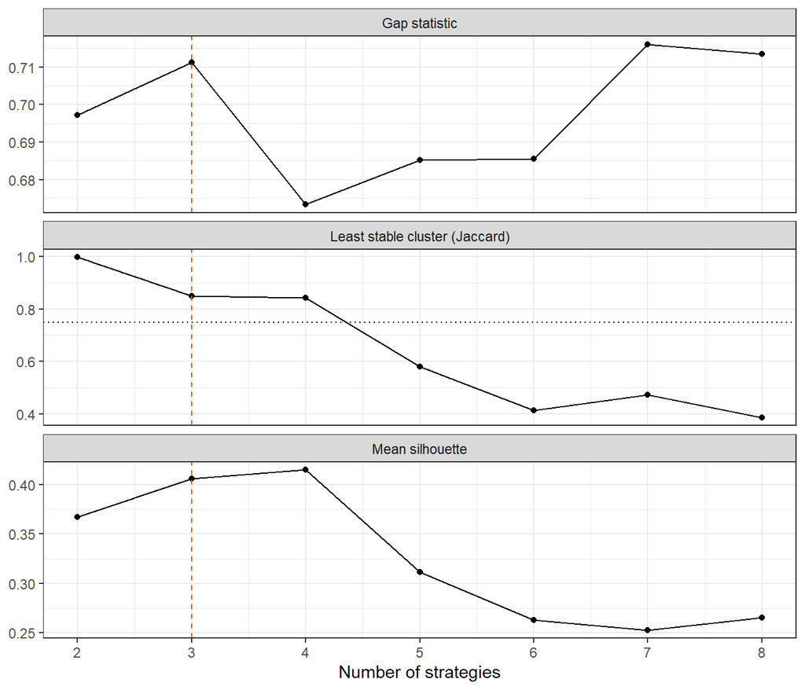

```r
kp <- k_tab %>% dplyr::select(k, gap, silhouette, min_jaccard) %>%
  pivot_longer(-k) %>%
  mutate(name = recode(name, gap = "Gap statistic", silhouette = "Mean silhouette",
                       min_jaccard = "Least stable cluster (Jaccard)"))
g <- ggplot(kp, aes(k, value)) + geom_line() + geom_point() +
  geom_vline(xintercept = K, colour = "#d95f02", linetype = 2) +
  geom_hline(data = data.frame(name = "Least stable cluster (Jaccard)", y = MIN_JACCARD),
             aes(yintercept = y), linetype = 3) +
  facet_wrap(~ name, ncol = 1, scales = "free_y") +
  scale_x_continuous(breaks = K_RANGE) + theme_bw() + labs(x = "Number of strategies", y = NULL)
g
```

```r
ggsave(file.path(FIG, "A_number_of_strategies.pdf"), g, width = 6, height = 7)
```

## 4.4 Is there cluster structure at all?

Clustering always returns groups, even from a continuum. Here the observed silhouette is compared with that obtained by applying the same clustering to 500 data sets simulated from a single multivariate normal distribution with the observed variance on each retained dimension (no groups). A p-value near or above 0.05 means the strategies are weakly separated and should be described as modes of a continuum rather than discrete groups.

```r
sds <- apply(S, 2, sd)
set.seed(SEED)
null_struct <- do.call(rbind, lapply(intersect(2:4, K_RANGE), function(k) {
  obs <- mean(silhouette(hcpc_lite(S, k), dist(S))[, 3])
  sim <- replicate(N_NULL, {
    Y <- sapply(sds, function(s) rnorm(nrow(S), 0, s))
    mean(silhouette(hcpc_lite(Y, k), dist(Y))[, 3])
  })
  data.frame(k = k, silhouette = obs, null_median = median(sim),
             null_95 = quantile(sim, 0.95), p = (1 + sum(sim >= obs)) / (N_NULL + 1))
}))
rownames(null_struct) <- NULL
null_struct %>% mutate(across(where(is.double), ~ round(.x, 3)))
```

```
##   k silhouette null_median null_95     p
## 1 2      0.367       0.258   0.300 0.002
## 2 3      0.406       0.221   0.255 0.002
## 3 4      0.415       0.214   0.244 0.002
```

```r
write.csv(null_struct, file.path(OUT, "A_null_structure_test.csv"), row.names = FALSE)
```

## 4.5 Choosing between k = 2 and k = 3

Internal criteria cannot settle every choice: when two solutions are close, the choice should rest on (i) whether the finer solution is a refinement of the coarser one, (ii) whether the extra group is reproducible, and (iii) whether it differs in variables that were **not** used to build the clusters (external validation; Hennig 2015, *Pattern Recognition Letters* 64:53–62).

### 4.5.1 1. What the gap statistic actually says

The 1-SE rule picks the *smallest* k whose gap is within one standard error of the next; it is deliberately conservative. Other standard rules (Tibshirani et al. 2001; Dudoit & Fridlyand 2002) are shown for comparison.

```r
sapply(c("Tibs2001SEmax", "firstSEmax", "firstmax", "globalSEmax", "globalmax"),
       function(m) maxSE(gs$Tab[, "gap"], gs$Tab[, "SE.sim"], method = m))
```

```
## Tibs2001SEmax    firstSEmax      firstmax   globalSEmax     globalmax
##             2             2             3             2             7
```

```r
k_tab %>% filter(k %in% 2:4) %>%
  dplyr::select(k, gap, gap_se, silhouette, sizes, min_size, min_jaccard, passes) %>%
  mutate(across(where(is.double), ~ round(.x, 3)))
```

```
##   k   gap gap_se silhouette     sizes min_size min_jaccard passes
## 1 2 0.697  0.026      0.367     53/40       40       0.997   TRUE
## 2 3 0.711  0.027      0.406   48/39/6        6       0.850   TRUE
## 3 4 0.673  0.026      0.415 48/39/5/1        1       0.841  FALSE
```

### 4.5.2 2. Is k = 3 a refinement of k = 2, and is the extra group stable?

```r
l2 <- stab[["2"]]$ref; l3 <- stab[["3"]]$ref
table(`k = 2` = l2, `k = 3` = l3)
```

```
##      k = 3
## k = 2  1  2  3
##     1 47  0  6
##     2  1 39  0
```

```r
new_grp   <- as.integer(names(which.min(table(l3))))                 # group added at k = 3
parent    <- as.integer(names(which.max(table(l2[l3 == new_grp])))) # k = 2 cluster it comes from
in_parent <- l2 == parent
split_grp <- l3 == new_grp & in_parent
cat("k = 3 separates", sum(split_grp), "seals from a k = 2 cluster of", sum(in_parent),
    "; Jaccard stability of that group:", round(stab[["3"]]$jaccard[new_grp], 2), "\n")
```

```
## k = 3 separates 6 seals from a k = 2 cluster of 53 ; Jaccard stability of that group: 0.85
```

```r
# How the split-off group differs behaviourally from the rest of its parent cluster
data.frame(scale(dat[BEHAV]))[in_parent, ] %>%
  mutate(group = ifelse(split_grp[in_parent], "split-off group", "rest of parent")) %>%
  group_by(group) %>% summarise(across(everything(), mean)) %>%
  pivot_longer(-group, names_to = "variable") %>%
  pivot_wider(names_from = group, values_from = value) %>%
  mutate(difference_z = `split-off group` - `rest of parent`) %>%
  arrange(desc(abs(difference_z))) %>% head(8) %>%
  mutate(across(where(is.double), ~ round(.x, 2)))
```

```
## # A tibble: 8 × 4
##   variable                      `rest of parent` `split-off group` difference_z
##   <chr>                                    <dbl>             <dbl>        <dbl>
## 1 MesoEcoProportionCAC                      0.02              2.63         2.61
## 2 Pct_BenthicDives                         -0.04              2.54         2.58
## 3 Mean_Duration_sec                        -0.27              2.01         2.29
## 4 MesoEcoProportionSubArcticPac             0.84             -1.07        -1.9
## 5 Mean_Duration_sd                         -0.03              1.74         1.77
## 6 MesoEcoProportionShelf                   -0.06              1.65         1.71
## 7 MaxLat_degrees                            0.72             -0.86        -1.58
## 8 PctTripDiving                             0.01              1.42         1.41
```

### 4.5.3 3. External validation: does the split-off group differ in variables not used for clustering?

Permutation test (difference in means, two-sided) between the split-off group and the rest of the cluster it comes from. Trip duration and mass-gain rate are completely independent of the clustering. Isotopes are shown too, but note that if they are used to justify k they are no longer a fully independent test in Part B — report this transparently.

```r
perm_diff <- function(x, g, B = N_PERM) {
  obs  <- mean(x[g]) - mean(x[!g])
  null <- replicate(B, { s <- sample(g); mean(x[s]) - mean(x[!s]) })
  c(n_split = sum(g), n_rest = sum(!g),
    mean_split = mean(x[g]), mean_rest = mean(x[!g]),
    difference = obs, p_perm = (1 + sum(abs(null) >= abs(obs))) / (B + 1))
}
ext_vars <- intersect(c("TripDuration_days", "MassGainRate_kgPerDay_Dcrocker", ISO), names(dat))
set.seed(SEED)
split_tests <- t(sapply(ext_vars, function(v) {
  ok <- in_parent & !is.na(dat[[v]])
  perm_diff(dat[[v]][ok], split_grp[ok])
}))
round(split_tests, 4)
```

```
##                                n_split n_rest mean_split mean_rest difference
## TripDuration_days                    6     47    57.0082   74.0123   -17.0040
## MassGainRate_kgPerDay_Dcrocker       6     47     1.7264    1.2303     0.4961
## d13C                                 6     47   -18.9183  -19.4923     0.5740
## d15N                                 6     47    15.5650   14.4464     1.1186
##                                p_perm
## TripDuration_days              0.0006
## MassGainRate_kgPerDay_Dcrocker 0.0030
## d13C                           0.0004
## d15N                           0.0012
```

```r
write.csv(split_tests, file.path(OUT, "A_k2_vs_k3_external_validation.csv"))
```

**Interpretation.** If the split-off group is (i) nested within a k = 2 cluster, (ii) stable (Jaccard ≥ 0.75), and (iii) different in independent variables, the k = 3 solution captures real biological structure that k = 2 merges. The two solutions are then best presented as two levels of one hierarchy: two main offshore modes, one of which contains a small, distinct strategy.

## 4.6 Final HCPC

```r
res.pca  <- PCA(X, ncp = N_DIM, graph = FALSE)
res.hcpc <- HCPC(res.pca, nb.clust = K, consol = TRUE, graph = FALSE)
cl <- as.integer(res.hcpc$data.clust$clust)
ref_K <- stab[[as.character(K)]]$ref
cat("Agreement with the bootstrap reference partition (ARI):",
    round(mclust::adjustedRandIndex(cl, ref_K), 3), "\n")
```

```
## Agreement with the bootstrap reference partition (ARI): 1
```

```r
# Jaccard values re-indexed to the HCPC cluster numbers
jac_cl <- stab[[as.character(K)]]$jaccard[
  sapply(1:K, function(j) as.integer(names(which.max(table(ref_K[cl == j])))))]

# Name each strategy by the mesoecoregion it uses most (relative to the population),
# and order strategies by size. Edit the names after looking at the profiles if needed.
zreg <- apply(scale(dat[names(REGIONS)]), 2, function(z) tapply(z, cl, mean))
nm <- make.unique(unname(REGIONS[apply(zreg, 1, which.max)]), sep = " ")
size_order <- order(table(cl), decreasing = TRUE)
dat$strategy <- factor(nm[cl], levels = nm[size_order])
COLS <- setNames(PAL[seq_len(K)], levels(dat$strategy))
table(dat$strategy)
```

```
##
##             Subarctic North Central Pacific    California Current
##                    48                    39                     6
```

```r
# Per-seal assignment confidence
dat$silhouette <- silhouette(cl, dist(S))[, 3]
dat$coassign   <- stab[[as.character(K)]]$coassign
data.frame(strategy = levels(dat$strategy),
           n = as.vector(table(dat$strategy)),
           jaccard = jac_cl[size_order],
           median_coassign = tapply(dat$coassign, dat$strategy, median),
           n_low_confidence = tapply(dat$coassign < LOW_CONFIDENCE, dat$strategy, sum)) %>%
  mutate(across(where(is.double), ~ round(.x, 2)))
```

```
##                                    strategy  n jaccard median_coassign
## Subarctic                         Subarctic 48    0.97            0.98
## North Central Pacific North Central Pacific 39    0.99            1.00
## California Current       California Current  6    0.85            0.91
##                       n_low_confidence
## Subarctic                            1
## North Central Pacific                0
## California Current                   1
```

```r
dat %>% filter(coassign < LOW_CONFIDENCE | silhouette < 0) %>%
  dplyr::select(TOPPID, ProcedureYear, strategy, silhouette, coassign)
```

```
##          TOPPID ProcedureYear           strategy silhouette  coassign
## 2012020 2012020          2012          Subarctic 0.00459274 0.5462438
## 2014015 2014015          2014 California Current 0.06645306 0.7788162
```

### 4.6.1 Dendrogram and factor map

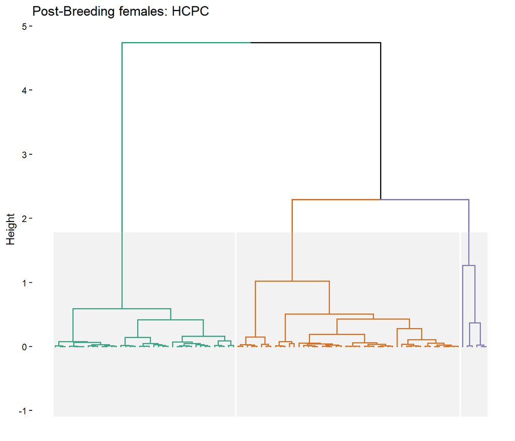

```r
fviz_dend(res.hcpc, cex = 0.5, palette = unname(PAL[seq_len(K)]), rect = TRUE,
          rect_fill = TRUE, show_labels = FALSE, main = "Post-Breeding females: HCPC")
```

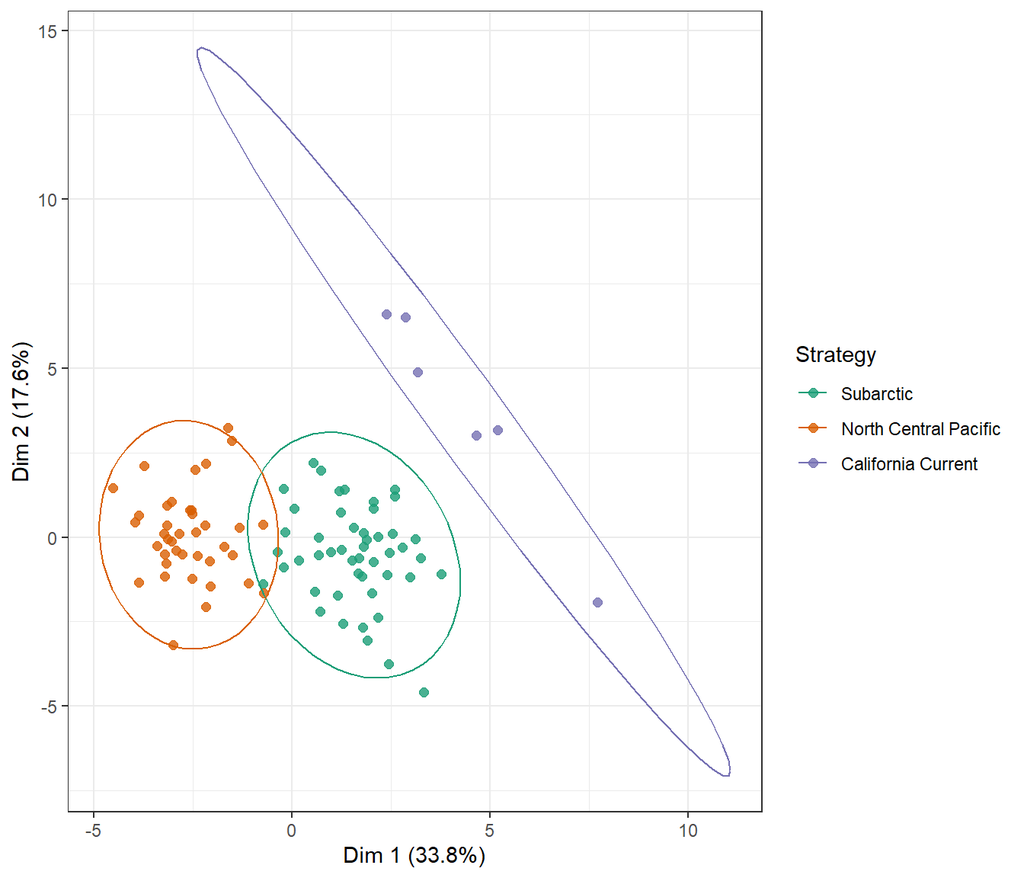

```r
g <- data.frame(Dim1 = S[, 1], Dim2 = S[, 2], strategy = dat$strategy) %>%
  ggplot(aes(Dim1, Dim2, colour = strategy)) +
  geom_point(size = 2, alpha = 0.8) + stat_ellipse(level = 0.95, type = "norm") +
  scale_colour_manual(values = COLS) + theme_bw() +
  labs(x = sprintf("Dim 1 (%.1f%%)", pc_tab$pct_var[1]),
       y = sprintf("Dim 2 (%.1f%%)", pc_tab$pct_var[2]), colour = "Strategy")
g
```

```r
ggsave(file.path(FIG, "A_factor_map.pdf"), g, width = 7, height = 5)
```

### 4.6.2 What characterises each strategy

`v.test` > 2 (or < −2) means the strategy mean is significantly above (below) the population mean. These tests are **descriptive**: the same variables built the clusters.

```r
desc <- res.hcpc$desc.var$quanti
names(desc) <- nm[as.integer(names(desc))]
lapply(desc, function(d)
  if (is.null(d)) "no variable differs from the population mean" else
    round(d[, c("v.test", "Mean in category", "Overall mean"), drop = FALSE], 2))
```

```
## $`North Central Pacific`
##                               v.test Mean in category Overall mean
## MesoEcoProportionNorthCPac      8.91             0.55         0.24
## SdDistContShelf_km              8.38           425.08       267.28
## MedianDistToContShelf_km        8.03           970.87       601.80
## Mean_Depth_m                    5.50           568.58       534.48
## Mean_Depth_sd                   2.66           166.01       158.51
## DeepNightForageDivesMedian_m   -2.29          -560.16      -546.01
## Pct_BenthicDives               -2.76             0.03         0.06
## Pct_DriftDives                 -2.93             7.01         7.97
## MesoEcoProportionCAC           -3.43             0.34         0.41
## MaxLat_degrees                 -6.06            44.11        47.36
## MinLon_degrees                 -6.52           212.34       218.55
## DeepDayForageDivesMedian_m     -6.61          -676.73      -630.37
## MesoEcoProportionSubArcticPac  -7.09             0.09         0.33
##
## $Subarctic
##                               v.test Mean in category Overall mean
## MesoEcoProportionSubArcticPac   8.32             0.56         0.33
## MaxLat_degrees                  7.06            50.48        47.36
## DeepDayForageDivesMedian_m      4.97          -601.72      -630.37
## MinLon_degrees                  4.25           221.88       218.55
## Mean_Depth_sd                  -2.83           151.95       158.51
## Mean_Duration_sec              -2.89          1302.44      1344.73
## Mean_Depth_m                   -3.87           514.77       534.48
## MedianDistToContShelf_km       -6.30           363.33       601.80
## SdDistContShelf_km             -6.62           164.73       267.28
## MesoEcoProportionNorthCPac     -7.79             0.01         0.24
##
## $`California Current`
##                               v.test Mean in category Overall mean
## MesoEcoProportionCAC            6.66             0.84         0.41
## Pct_BenthicDives                6.43             0.29         0.06
## Mean_Duration_sec               5.10          1638.30      1344.73
## MinLon_degrees                  4.46           232.30       218.55
## Mean_Duration_sd                4.41           384.63       299.21
## MesoEcoProportionShelf          4.17             0.12         0.03
## PctTripDiving                   3.60            93.11        91.50
## DeepDayForageDivesMedian_m      3.18          -558.24      -630.37
## Pct_DriftDives                  2.86            11.00         7.97
## DeepNightForageDivesMedian_m    2.44          -497.16      -546.01
## MesoEcoProportionNorthCPac     -2.07             0.00         0.24
## MaxLat_degrees                 -2.18            43.58        47.36
## MesoEcoProportionSubArcticPac  -2.70             0.04         0.33
## Pct_ForagingDives              -2.81            41.30        54.24
## Mean_Depth_m                   -3.19           470.56       534.48
## MedianDistToContShelf_km       -3.30           110.65       601.80
## Pct_TransitDives               -3.35            18.25        31.66
## SdDistContShelf_km             -3.37            62.00       267.28
```

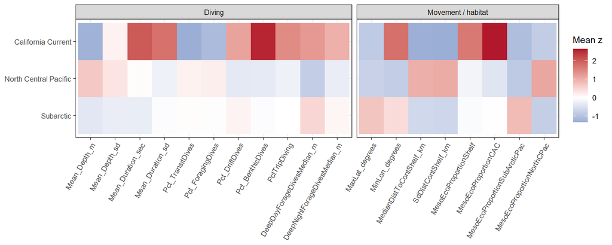

```r
prof <- data.frame(scale(dat[BEHAV]), strategy = dat$strategy) %>%
  pivot_longer(-strategy, names_to = "variable") %>%
  group_by(strategy, variable) %>% summarise(mean_z = mean(value), .groups = "drop") %>%
  mutate(block = ifelse(variable %in% SPACE, "Movement / habitat", "Diving"),
         variable = factor(variable, BEHAV))
g <- ggplot(prof, aes(variable, strategy, fill = mean_z)) + geom_tile() +
  facet_grid(~ block, scales = "free_x", space = "free_x") +
  scale_fill_gradient2(low = "#2166ac", high = "#b2182b") + theme_bw() +
  theme(axis.text.x = element_text(angle = 60, hjust = 1)) +
  labs(x = NULL, y = NULL, fill = "Mean z")
g
```

```r
ggsave(file.path(FIG, "A_strategy_profiles.pdf"), g, width = 11, height = 4.5)

# Mean (SD) of each variable by strategy
dat %>% group_by(strategy) %>%
  summarise(across(all_of(BEHAV), ~ sprintf("%.2f (%.2f)", mean(.x), sd(.x)))) %>%
  pivot_longer(-strategy, names_to = "variable") %>%
  pivot_wider(names_from = strategy, values_from = value)
```

```
## # A tibble: 19 × 4
##    variable                Subarctic North Central Pacifi…¹ `California Current`
##    <chr>                   <chr>     <chr>                  <chr>
##  1 MaxLat_degrees          50.48 (3… 44.11 (2.64)           43.58 (1.73)
##  2 MinLon_degrees          221.88 (… 212.34 (4.95)          232.30 (2.86)
##  3 MedianDistToContShelf_… 363.33 (… 970.87 (161.64)        110.65 (124.84)
##  4 SdDistContShelf_km      164.73 (… 425.08 (53.56)         62.00 (54.65)
##  5 MesoEcoProportionShelf  0.02 (0.… 0.02 (0.02)            0.12 (0.21)
##  6 MesoEcoProportionCAC    0.41 (0.… 0.34 (0.07)            0.84 (0.20)
##  7 MesoEcoProportionSubAr… 0.56 (0.… 0.09 (0.15)            0.04 (0.08)
##  8 MesoEcoProportionNorth… 0.01 (0.… 0.55 (0.16)            0.00 (0.00)
##  9 Mean_Depth_m            514.77 (… 568.58 (36.44)         470.56 (98.00)
## 10 Mean_Depth_sd           151.95 (… 166.01 (19.14)         162.22 (17.17)
## 11 Mean_Duration_sec       1302.44 … 1351.61 (107.68)       1638.30 (305.61)
## 12 Mean_Duration_sd        297.23 (… 288.49 (35.88)         384.63 (106.21)
## 13 Pct_TransitDives        31.99 (8… 33.32 (10.38)          18.25 (10.61)
## 14 Pct_ForagingDives       53.91 (1… 56.64 (10.75)          41.30 (15.70)
## 15 Pct_DriftDives          8.37 (2.… 7.01 (2.27)            11.00 (2.16)
## 16 Pct_BenthicDives        0.06 (0.… 0.03 (0.02)            0.29 (0.26)
## 17 PctTripDiving           91.51 (0… 91.25 (1.10)           93.11 (1.32)
## 18 DeepDayForageDivesMedi… -601.72 … -676.73 (35.67)        -558.24 (72.99)
## 19 DeepNightForageDivesMe… -540.62 … -560.16 (47.62)        -497.16 (120.79)
## # ℹ abbreviated name: ¹`North Central Pacific`
```

## 4.7 Sensitivity of the strategies

Each alternative is compared with the final partition with the adjusted Rand index (ARI = 1: identical; > 0.8: very similar).

```r
ari <- function(a, b) round(mclust::adjustedRandIndex(a, b), 3)
sens <- list()

for (nd in setdiff(c(N_DIM - 1, N_DIM + 1, length(BEHAV)), 1))
  sens[[paste("Dimensions =", nd)]] <- ari(cl, hcpc_lite(pc_scores(X, nd), K))

mfa <- MFA(X, group = c(length(SPACE), length(DIVE)), type = c("s", "s"),
           name.group = c("Space", "Diving"), ncp = N_DIM, graph = FALSE)
sens[["MFA (blocks weighted equally)"]] <- ari(cl, hcpc_lite(mfa$ind$coord[, 1:N_DIM], K))

sk <- names(which(abs(sapply(X, skew)) > SKEW_THRESHOLD & sapply(X, min) >= 0))
Xlog <- X; Xlog[sk] <- lapply(X[sk], function(x) log(x + max(min(x[x > 0]) / 2, 1e-6)))
sens[["Log-transform skewed variables"]] <- ari(cl, hcpc_lite(pc_scores(Xlog, N_DIM), K))

Xred <- X[setdiff(BEHAV, c("SdDistContShelf_km", "MesoEcoProportionNorthCPac"))]
sens[["Drop redundant SdDist + NorthCPac"]] <- ari(cl, hcpc_lite(pc_scores(Xred, N_DIM), K))

sens[["Ward without consolidation"]] <- ari(cl, cutree(hclust(dist(S), "ward.D2"), K))
set.seed(SEED)
sens[["k-means (100 starts)"]] <- ari(cl, kmeans(S, K, nstart = 100)$cluster)

md2 <- mahalanobis(S, colMeans(S), cov(S))
out <- md2 > qchisq(0.999, N_DIM)
cat("Multivariate outliers (p < 0.001):", paste(dat$TOPPID[out], collapse = ", "), "\n")
```

```
## Multivariate outliers (p < 0.001): 2014015
```

```r
if (any(out)) sens[["Without multivariate outliers"]] <-
  ari(cl[!out], hcpc_lite(pc_scores(X[!out, ], N_DIM), K))

one <- !duplicated(ifelse(is.na(dat$MainID), dat$TOPPID, dat$MainID))
sens[["One trip per seal"]] <- ari(cl[one], hcpc_lite(pc_scores(X[one, ], N_DIM), K))

sens_tab <- data.frame(scenario = names(sens), ARI = unlist(sens), row.names = NULL)
sens_tab
```

```
##                             scenario   ARI
## 1                     Dimensions = 3 1.000
## 2                     Dimensions = 5 1.000
## 3                    Dimensions = 19 1.000
## 4      MFA (blocks weighted equally) 0.975
## 5     Log-transform skewed variables 0.934
## 6  Drop redundant SdDist + NorthCPac 0.959
## 7         Ward without consolidation 0.770
## 8               k-means (100 starts) 1.000
## 9      Without multivariate outliers 0.958
## 10                 One trip per seal 1.000
```

```r
write.csv(sens_tab, file.path(OUT, "A_sensitivity.csv"), row.names = FALSE)

write.csv(dat %>% dplyr::select(TOPPID, MainID, ProcedureYear, strategy, silhouette, coassign),
          file.path(OUT, "A_strategy_assignments.csv"), row.names = FALSE)
```

## 4.8 Strategies and year

```r
table(dat$strategy, dat$ProcedureYear)
```

```
##
##                         2009 2010 2011 2012 2013 2014
##   Subarctic               10    7    6    8    6   11
##   North Central Pacific    5    6   11    8    7    2
##   California Current       0    0    1    1    1    3
```

```r
fisher.test(table(dat$strategy, dat$ProcedureYear), simulate.p.value = TRUE, B = 1e4)
```

```
##
##  Fisher's Exact Test for Count Data with simulated p-value (based on
##  10000 replicates)
##
## data:  table(dat$strategy, dat$ProcedureYear)
## p-value = 0.1312
## alternative hypothesis: two.sided
```

# 5 Part B — Isotopic niches of the strategies

Isotopes were not used to define the strategies, so differences here are an independent result. State which tissue was sampled and the period it integrates relative to the tracked trip. Isotopic baselines vary among years, so year is included as a covariate in the tests and checked in the sensitivity analysis.

## 5.1 Helper functions

```r
# Freedman-Lane permutation F test for `term`, adjusting for `covars`
fl_test <- function(d, response, term = "strategy", covars = character(0), B = N_PERM) {
  v  <- c(response, term, covars)
  d  <- d[complete.cases(d[v]), v, drop = FALSE]
  X0 <- model.matrix(reformulate(if (length(covars)) covars else "1"), d)
  X1 <- model.matrix(reformulate(c(covars, term)), d)
  y  <- d[[response]]
  Fstat <- function(y) {
    m0 <- lm.fit(X0, y); m1 <- lm.fit(X1, y)
    r0 <- sum(m0$residuals^2); r1 <- sum(m1$residuals^2)
    ((r0 - r1) / (m1$rank - m0$rank)) / (r1 / (nrow(X1) - m1$rank))
  }
  F_obs <- Fstat(y)
  m0 <- lm.fit(X0, y); fit0 <- y - m0$residuals
  F_p <- replicate(B, Fstat(fit0 + sample(m0$residuals)))
  data.frame(response = response,
             covariates = if (length(covars)) paste(covars, collapse = " + ") else "none",
             n = nrow(d), F = F_obs, p_perm = (1 + sum(F_p >= F_obs)) / (B + 1))
}

# All pairwise differences between strategies from an lm, with CIs
pair_contrasts <- function(fit, term = "strategy", level = 0.95) {
  b <- coef(fit); V <- vcov(fit)
  lev <- levels(model.frame(fit)[[term]]); cn <- paste0(term, lev)
  tq <- qt(1 - (1 - level) / 2, fit$df.residual)
  do.call(rbind, combn(seq_along(lev), 2, simplify = FALSE, FUN = function(ij) {
    L <- setNames(numeric(length(b)), names(b))
    if (cn[ij[2]] %in% names(b)) L[cn[ij[2]]] <- 1
    if (cn[ij[1]] %in% names(b)) L[cn[ij[1]]] <- L[cn[ij[1]]] - 1
    est <- sum(L * b); se <- sqrt(drop(t(L) %*% V %*% L))
    data.frame(contrast = paste(lev[ij[2]], "-", lev[ij[1]]),
               estimate = est, lwr = est - tq * se, upr = est + tq * se)
  }))
}

# Bayesian niche summaries (nicheROVER, default non-informative prior)
iso_niche <- function(d, nsamples = N_POST, seed = SEED) {
  set.seed(seed)
  par <- tapply(seq_len(nrow(d)), droplevels(d$strategy),
                function(ii) niw.post(nsamples = nsamples, X = as.matrix(d[ii, ISO])))
  nr95 <- sapply(par, function(sp) apply(sp$Sigma, 3, niche.size, alpha = 0.95))
  seab <- sapply(par, function(sp) apply(sp$Sigma, 3, function(Sg) pi * sqrt(det(Sg))))
  set.seed(seed)
  ov <- overlap(par, nreps = nsamples, nprob = nsamples, alpha = c(0.95, 0.99))
  list(par = par, nr95 = nr95, seab = seab, overlap = ov)
}
```

## 5.2 Isotopic values by strategy

```r
dat %>% group_by(strategy) %>%
  summarise(n = n(),
            d13C = sprintf("%.2f ± %.2f", mean(d13C), sd(d13C)),
            d15N = sprintf("%.2f ± %.2f", mean(d15N), sd(d15N)))
```

```
## # A tibble: 3 × 4
##   strategy                  n d13C          d15N
##   <fct>                 <int> <chr>         <chr>
## 1 Subarctic                48 -19.50 ± 0.24 14.43 ± 0.73
## 2 North Central Pacific    39 -19.44 ± 0.21 14.78 ± 0.87
## 3 California Current        6 -18.92 ± 0.31 15.56 ± 0.78
```

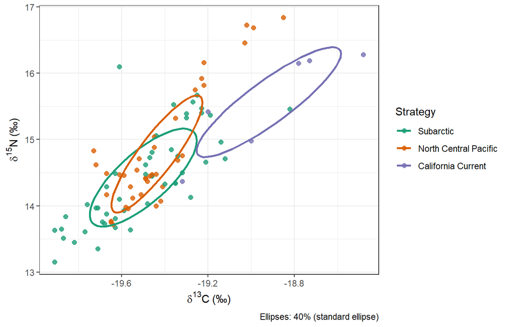

```r
g <- ggplot(dat, aes(d13C, d15N, colour = strategy)) +
  geom_point(size = 2, alpha = 0.8) +
  stat_ellipse(level = 0.40, type = "norm", linewidth = 0.9) +   # ~ standard ellipse
  scale_colour_manual(values = COLS) + theme_bw() +
  labs(x = expression(delta^{13}*C~"(‰)"), y = expression(delta^{15}*N~"(‰)"),
       colour = "Strategy", caption = "Ellipses: 40% (standard ellipse)")
g
```

```r
ggsave(file.path(FIG, "B_isotopes_by_strategy.pdf"), g, width = 7, height = 5, device = cairo_pdf)
```

## 5.3 Do strategies differ in isotopic values?

```r
set.seed(SEED)
iso_tests <- bind_rows(lapply(ISO, function(v) bind_rows(
  fl_test(dat, v), fl_test(dat, v, covars = "ProcedureYear"))))
iso_tests$p_BH <- p.adjust(iso_tests$p_perm, "BH")
iso_tests %>% mutate(across(c(F, p_perm, p_BH), ~ signif(.x, 3)))
```

```
##   response    covariates  n     F p_perm   p_BH
## 1     d13C          none 93 16.50 0.0002 0.0004
## 2     d13C ProcedureYear 93 16.10 0.0002 0.0004
## 3     d15N          none 93  6.45 0.0024 0.0026
## 4     d15N ProcedureYear 93  6.65 0.0026 0.0026
```

```r
fits <- lapply(setNames(ISO, ISO), function(v)
  lm(reformulate(c("strategy", "ProcedureYear"), v), data = dat))
contr <- bind_rows(lapply(fits, pair_contrasts), .id = "isotope")
contr %>% mutate(across(where(is.numeric), ~ round(.x, 3)))
```

```
##   isotope                                   contrast estimate    lwr   upr
## 1    d13C          North Central Pacific - Subarctic    0.070 -0.034 0.175
## 2    d13C             California Current - Subarctic    0.587  0.381 0.793
## 3    d13C California Current - North Central Pacific    0.516  0.304 0.729
## 4    d15N          North Central Pacific - Subarctic    0.403  0.044 0.761
## 5    d15N             California Current - Subarctic    1.155  0.449 1.860
## 6    d15N California Current - North Central Pacific    0.752  0.024 1.480
```

```r
write.csv(bind_rows(iso_tests), file.path(OUT, "B_isotope_tests.csv"), row.names = FALSE)
write.csv(contr, file.path(OUT, "B_isotope_contrasts.csv"), row.names = FALSE)
```

### 5.3.1 Isotopic differences with k = 2 vs k = 3

```r
set.seed(SEED)
bind_rows(lapply(2:3, function(k) {
  d <- dat; d$strategy <- factor(stab[[as.character(k)]]$ref)
  bind_rows(lapply(ISO, function(v) fl_test(d, v, covars = "ProcedureYear"))) %>% mutate(k = k)
})) %>% dplyr::select(k, response, n, F, p_perm) %>% mutate(across(c(F, p_perm), ~ signif(.x, 3)))
```

```
##   k response  n        F p_perm
## 1 2     d13C 93  0.00469 0.9460
## 2 2     d15N 93  1.61000 0.2120
## 3 3     d13C 93 16.10000 0.0002
## 4 3     d15N 93  6.65000 0.0026
```

### 5.3.2 Equivalence: are some strategies isotopically indistinguishable?

A non-significant test is not evidence of no difference. Two one-sided tests (TOST): two strategies are considered equivalent if the 90 % CI of their difference lies inside ±margin (`EQUIV`).

```r
tost <- bind_rows(lapply(ISO, function(v) {
  ci <- pair_contrasts(fits[[v]], level = 0.90)
  data.frame(isotope = v, ci, margin = EQUIV[[v]],
             equivalent = ci$lwr > -EQUIV[[v]] & ci$upr < EQUIV[[v]],
             different  = ci$lwr > 0 | ci$upr < 0)
}))
tost %>% mutate(across(where(is.numeric), ~ round(.x, 3)))
```

```
##   isotope                                   contrast estimate    lwr   upr
## 1    d13C          North Central Pacific - Subarctic    0.070 -0.017 0.158
## 2    d13C             California Current - Subarctic    0.587  0.414 0.759
## 3    d13C California Current - North Central Pacific    0.516  0.338 0.694
## 4    d15N          North Central Pacific - Subarctic    0.403  0.103 0.702
## 5    d15N             California Current - Subarctic    1.155  0.565 1.745
## 6    d15N California Current - North Central Pacific    0.752  0.143 1.361
##   margin equivalent different
## 1    0.3       TRUE     FALSE
## 2    0.3      FALSE      TRUE
## 3    0.3      FALSE      TRUE
## 4    1.0       TRUE      TRUE
## 5    1.0      FALSE      TRUE
## 6    1.0      FALSE      TRUE
```

```r
write.csv(tost, file.path(OUT, "B_isotope_equivalence.csv"), row.names = FALSE)
```

### 5.3.3 Figure: isotope differences against the equivalence margins (Fig. 2c)

Each strategy pair is shown with its year-adjusted difference, the 95 % CI (thin line, test of difference) and the 90 % CI (thick line, equivalence test). The shaded band is the equivalence margin. A pair is “equivalent” when the thick line lies inside the band, and “different” when the thin line excludes zero; both can be true (different, but negligibly so).

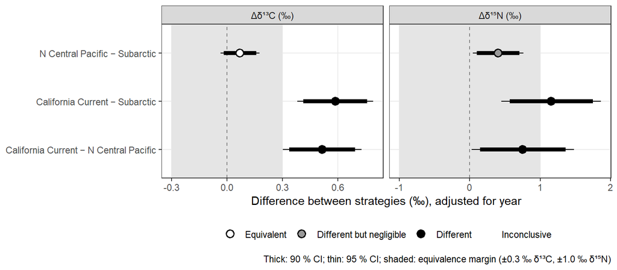

```r
ISO_LAB <- c(d13C = "Δδ¹³C (‰)", d15N = "Δδ¹⁵N (‰)")
eq <- tost %>%
  dplyr::select(isotope, contrast, estimate, lwr90 = lwr, upr90 = upr, margin, equivalent) %>%
  left_join(contr %>% dplyr::select(isotope, contrast, lwr95 = lwr, upr95 = upr),
            by = c("isotope", "contrast")) %>%
  mutate(different = lwr95 > 0 | upr95 < 0,
         verdict = dplyr::case_when(equivalent & different ~ "Different but negligible",
                                    equivalent ~ "Equivalent",
                                    different ~ "Different",
                                    TRUE ~ "Inconclusive"),
         verdict = factor(verdict, c("Equivalent", "Different but negligible", "Different", "Inconclusive")),
         contrast = gsub("North Central Pacific", "N Central Pacific", contrast),
         contrast = factor(gsub(" - ", " − ", contrast)),
         contrast = factor(contrast, rev(unique(as.character(contrast)))))
mdf <- data.frame(isotope = names(EQUIV), margin = unname(EQUIV))

g_eq <- ggplot(eq, aes(estimate, contrast)) +
  geom_rect(data = mdf, aes(xmin = -margin, xmax = margin, ymin = -Inf, ymax = Inf),
            inherit.aes = FALSE, fill = "grey90") +
  geom_vline(xintercept = 0, linetype = 2, colour = "grey50") +
  geom_linerange(aes(xmin = lwr95, xmax = upr95), linewidth = 0.5) +
  geom_linerange(aes(xmin = lwr90, xmax = upr90), linewidth = 1.8) +
  geom_point(aes(fill = verdict), shape = 21, size = 3, stroke = 0.8) +
  facet_wrap(~ isotope, scales = "free_x", labeller = as_labeller(ISO_LAB)) +
  scale_fill_manual(values = c(Equivalent = "white", `Different but negligible` = "grey60",
                               Different = "black", Inconclusive = "#fdae61"),
                    drop = FALSE, name = NULL) +
  theme_bw() + theme(legend.position = "bottom", panel.grid.minor = element_blank()) +
  labs(x = "Difference between strategies (‰), adjusted for year", y = NULL,
       caption = sprintf("Thick: 90 %% CI; thin: 95 %% CI; shaded: equivalence margin (±%.1f ‰ δ¹³C, ±%.1f ‰ δ¹⁵N)",
                         EQUIV[["d13C"]], EQUIV[["d15N"]]))
g_eq
```

```r
ggsave(file.path(FIG, "B_isotope_equivalence.pdf"), g_eq, width = 8, height = 3.5, device = cairo_pdf)
```

## 5.4 Isotopic niche size and overlap (nicheROVER)

nicheROVER is used with its **default, non-informative prior** and a fixed seed. Niche size is reported as the 95 % niche region (nicheROVER) and as the Bayesian standard ellipse area (SEA_B = π√|Σ|, comparable with SIBER); SEAc is the small-sample-corrected standard ellipse area from the data.

```r
nb <- iso_niche(dat)

sea_c <- tapply(seq_len(n), dat$strategy, function(ii) {
  m <- length(ii); pi * sqrt(det(cov(dat[ii, ISO]))) * (m - 1) / (m - 2) })
size_tab <- data.frame(strategy = levels(dat$strategy), n = as.vector(table(dat$strategy)),
  SEAc = as.vector(sea_c),
  SEAb_median = apply(nb$seab, 2, median),
  SEAb_lwr = apply(nb$seab, 2, quantile, 0.025), SEAb_upr = apply(nb$seab, 2, quantile, 0.975),
  NR95_median = apply(nb$nr95, 2, median),
  NR95_lwr = apply(nb$nr95, 2, quantile, 0.025), NR95_upr = apply(nb$nr95, 2, quantile, 0.975))
size_tab %>% mutate(across(where(is.double), ~ round(.x, 3)))
```

```
##                                    strategy  n  SEAc SEAb_median SEAb_lwr
## Subarctic                         Subarctic 48 0.372       0.352    0.270
## North Central Pacific North Central Pacific 39 0.280       0.261    0.195
## California Current       California Current  6 0.452       0.270    0.139
##                       SEAb_upr NR95_median NR95_lwr NR95_upr
## Subarctic                0.473       2.108    1.616    2.837
## North Central Pacific    0.357       1.562    1.166    2.137
## California Current       0.635       1.620    0.830    3.804
```

```r
write.csv(size_tab, file.path(OUT, "B_niche_size.csv"), row.names = FALSE)

# Posterior probability that the row strategy has a larger niche than the column strategy
lev <- levels(dat$strategy)
round(outer(lev, lev, Vectorize(function(a, b) mean(nb$seab[, a] > nb$seab[, b]))), 3) %>%
  `dimnames<-`(list(lev, lev))
```

```
##                       Subarctic North Central Pacific California Current
## Subarctic                 0.000                 0.921              0.732
## North Central Pacific     0.079                 0.000              0.465
## California Current        0.268                 0.535              0.000
```

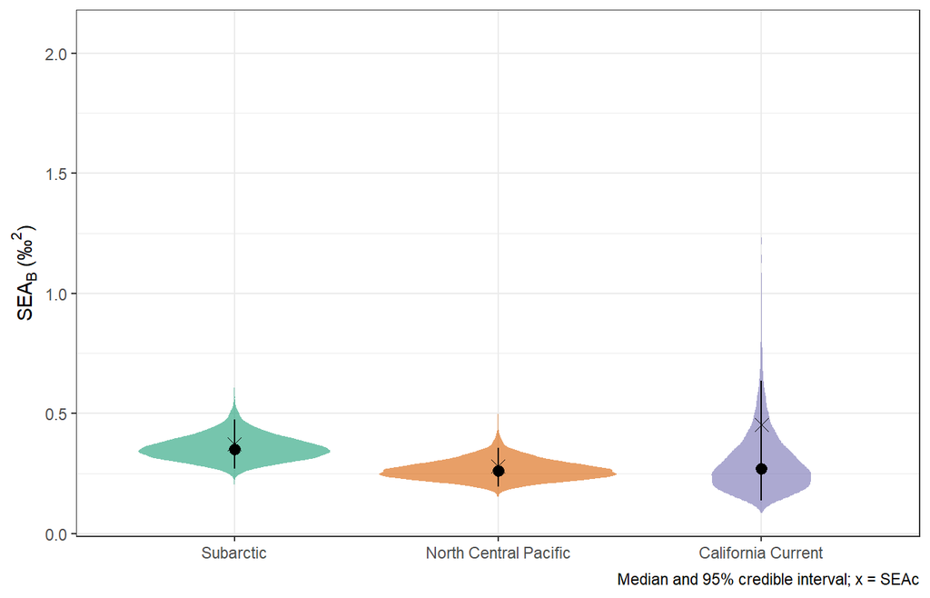

```r
g <- as.data.frame(nb$seab) %>% pivot_longer(everything(), names_to = "strategy") %>%
  mutate(strategy = factor(strategy, lev)) %>%
  ggplot(aes(strategy, value, fill = strategy)) +
  geom_violin(alpha = 0.6, colour = NA) +
  stat_summary(fun.data = function(x) data.frame(y = median(x), ymin = quantile(x, .025),
                                                 ymax = quantile(x, .975))) +
  geom_point(data = size_tab, aes(strategy, SEAc), shape = 4, size = 3, inherit.aes = FALSE) +
  scale_fill_manual(values = COLS, guide = "none") + theme_bw() +
  labs(x = NULL, y = expression("SEA"[B]~"(‰"^2*")"),
       caption = "Median and 95% credible interval; x = SEAc")
g
```

```r
ggsave(file.path(FIG, "B_niche_size.pdf"), g, width = 6, height = 4.5, device = cairo_pdf)
```

**Overlap.** Entry [row, column] is the probability (%) that an individual of the row strategy falls inside the 95 % niche region of the column strategy. Overlap is directional, so the two directions can differ.

```r
ov_mean <- apply(nb$overlap, c(1:2, 4), mean) * 100
ov_ci   <- apply(nb$overlap * 100, c(1:2, 4), quantile, prob = c(0.025, 0.975), na.rm = TRUE)
round(ov_mean[, , 1], 1)
```

```
##                        Species B
## Species A               Subarctic North Central Pacific California Current
##   Subarctic                    NA                  79.5               41.2
##   North Central Pacific      90.7                    NA               37.5
##   California Current         44.8                  22.6                 NA
```

```r
round(ov_ci[, , , 1], 1)
```

```
## , , Species B = Subarctic
##
##        Species A
##         Subarctic North Central Pacific California Current
##   2.5%         NA                  79.2               14.4
##   97.5%        NA                  98.0               78.2
##
## , , Species B = North Central Pacific
##
##        Species A
##         Subarctic North Central Pacific California Current
##   2.5%       65.4                    NA                3.7
##   97.5%      91.2                    NA               51.8
##
## , , Species B = California Current
##
##        Species A
##         Subarctic North Central Pacific California Current
##   2.5%        9.2                   3.3                 NA
##   97.5%      84.6                  84.0                 NA
```

```r
ov_long <- expand.grid(from = lev, into = lev, stringsAsFactors = FALSE) %>% filter(from != into) %>%
  mutate(mean = mapply(function(a, b) ov_mean[a, b, 1], from, into),
         lwr  = mapply(function(a, b) ov_ci[1, a, b, 1], from, into),
         upr  = mapply(function(a, b) ov_ci[2, a, b, 1], from, into))
write.csv(ov_long, file.path(OUT, "B_niche_overlap_95.csv"), row.names = FALSE)
```

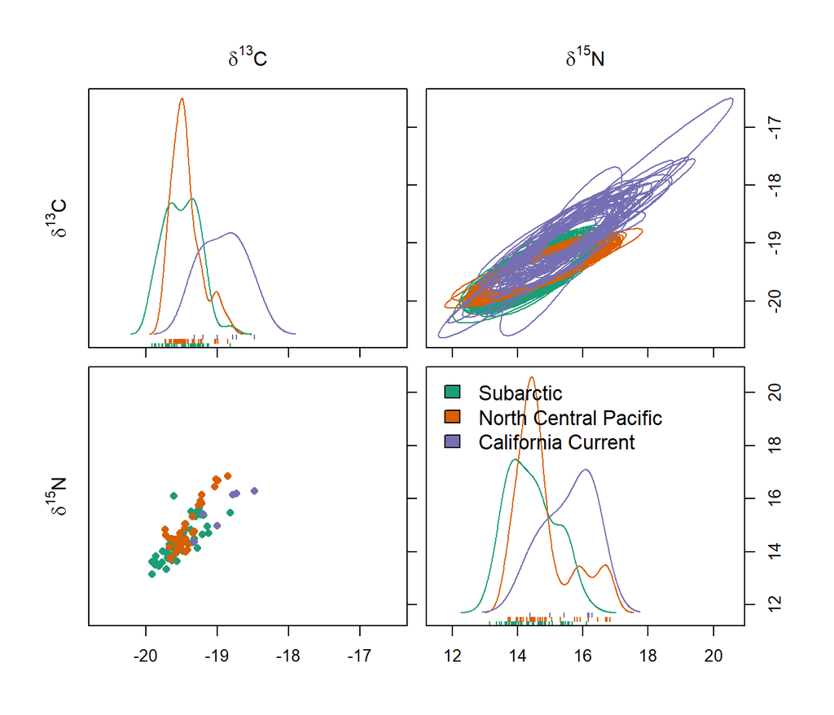

```r
set.seed(SEED)
par50 <- tapply(seq_len(n), dat$strategy,
                function(ii) niw.post(nsamples = 50, X = as.matrix(dat[ii, ISO])))
dat_l <- tapply(seq_len(n), dat$strategy, function(ii) as.matrix(dat[ii, ISO]))
niche.plot(niche.par = par50, niche.data = dat_l, pfrac = 0.05,
           iso.names = expression(delta^{13}*C, delta^{15}*N), col = unname(COLS))
```

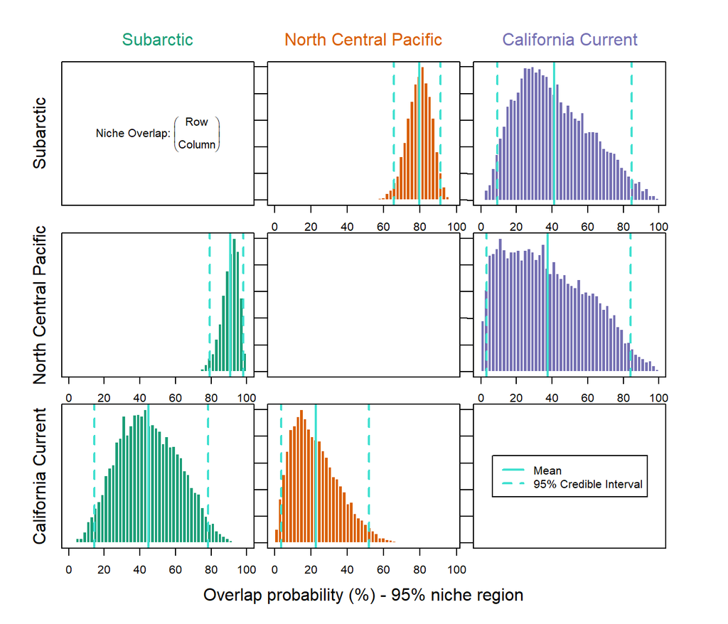

```r
overlap.plot(nb$overlap[, , , 1], col = unname(COLS), mean.cred.col = "turquoise",
             equal.axis = TRUE, xlab = "Overlap probability (%) - 95% niche region")
```

## 5.5 Isotopic niche size and overlap (SIBER)

SIBER (Jackson et al. 2011) gives the standard measures of isotopic niche width: the sample-size-corrected standard ellipse area (SEAc) and its Bayesian estimate (SEA_B, fitted in JAGS). Overlap is the **area** shared by two ellipses (here the 95 % ellipses), expressed as a proportion of the combined area (symmetric) and of each ellipse (directional). Unlike nicheROVER’s probabilistic overlap, it is purely geometric, so the two are not directly comparable. This section is skipped if JAGS is not installed.

```r
# SIBER needs columns iso1, iso2, group, community; simple group codes avoid
# problems with spaces in names (lookup table below)
codes <- setNames(paste0("S", seq_along(lev)), lev)
siber_df <- data.frame(iso1 = dat$d13C, iso2 = dat$d15N,
                       group = unname(codes[as.character(dat$strategy)]), community = 1)
siber <- SIBER::createSiberObject(siber_df)
ell_id <- paste0("1.", codes)                 # ellipse identifiers: "community.group"
names(ell_id) <- lev
data.frame(strategy = lev, code = codes, ellipse = ell_id, row.names = NULL)
```

```
##                strategy code ellipse
## 1             Subarctic   S1    1.S1
## 2 North Central Pacific   S2    1.S2
## 3    California Current   S3    1.S3
```

```r
# Maximum-likelihood metrics (TA = convex hull area, SEA, SEAc)
ml <- SIBER::groupMetricsML(siber)
colnames(ml) <- lev[match(colnames(ml), ell_id)]
round(ml, 3)
```

```
##      Subarctic North Central Pacific California Current
## TA       1.562                 0.918              0.461
## SEA      0.364                 0.272              0.362
## SEAc     0.372                 0.280              0.452
```

```r
# Bayesian standard ellipses
set.seed(SEED)
ell_post <- SIBER::siberMVN(siber, SIBER_PARMS, SIBER_PRIORS)
sea_b_siber <- SIBER::siberEllipses(ell_post)
colnames(sea_b_siber) <- lev[match(names(ell_post), ell_id)]

siber_size <- data.frame(strategy = colnames(sea_b_siber),
  n = as.vector(table(dat$strategy)[colnames(sea_b_siber)]),
  SEAc = ml["SEAc", colnames(sea_b_siber)],
  SEAb_mode = apply(sea_b_siber, 2, function(x) { dd <- density(x); dd$x[which.max(dd$y)] }),
  SEAb_median = apply(sea_b_siber, 2, median),
  SEAb_lwr = apply(sea_b_siber, 2, quantile, 0.025),
  SEAb_upr = apply(sea_b_siber, 2, quantile, 0.975), row.names = NULL)
siber_size %>% mutate(across(where(is.double), ~ round(.x, 3)))
```

```
##                strategy  n  SEAc SEAb_mode SEAb_median SEAb_lwr SEAb_upr
## 1             Subarctic 48 0.372     0.375       0.377    0.288    0.506
## 2 North Central Pacific 39 0.280     0.292       0.296    0.218    0.413
## 3    California Current  6 0.452     0.443       0.558    0.270    1.453
```

```r
write.csv(siber_size, file.path(OUT, "B_SIBER_niche_size.csv"), row.names = FALSE)

# Posterior probability that the row strategy has a larger SEA_B than the column strategy
round(outer(colnames(sea_b_siber), colnames(sea_b_siber),
            Vectorize(function(a, b) mean(sea_b_siber[, a] > sea_b_siber[, b]))), 3) %>%
  `dimnames<-`(list(colnames(sea_b_siber), colnames(sea_b_siber)))
```

```
##                       Subarctic North Central Pacific California Current
## Subarctic                 0.000                 0.864              0.172
## North Central Pacific     0.136                 0.000              0.058
## California Current        0.828                 0.942              0.000
```

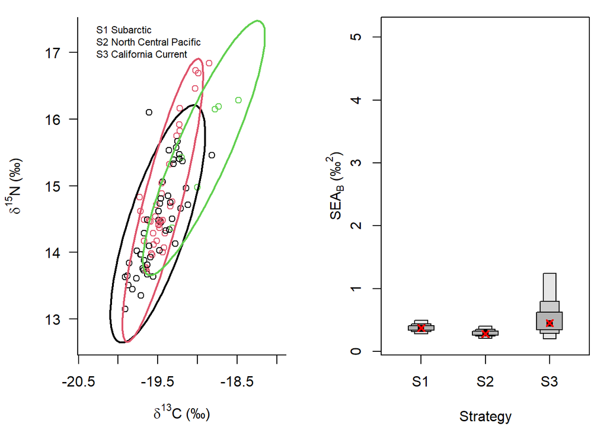

```r
par(mfrow = c(1, 2), mar = c(4.5, 4.5, 1, 1))
SIBER::plotSiberObject(siber, ax.pad = 0.5, hulls = FALSE, ellipses = TRUE,
                       group.ellipses.args = list(lty = 1, lwd = 2, p.interval = SIBER_P),
                       group.hulls = FALSE, bty = "L", iso.order = c(1, 2),
                       xlab = expression(delta^{13}*C~"(‰)"),
                       ylab = expression(delta^{15}*N~"(‰)"))
legend("topleft", legend = paste(codes, names(codes)), bty = "n", cex = 0.7)
SIBER::siberDensityPlot(sea_b_siber, xticklabels = codes[colnames(sea_b_siber)],
                        xlab = "Strategy", ylab = expression("SEA"[B]~"(‰"^2*")"))
points(seq_len(ncol(sea_b_siber)), siber_size$SEAc, col = "red", pch = 4, lwd = 2)
```

```r
par(mfrow = c(1, 1))
```

```r
pairs_s <- combn(lev, 2, simplify = FALSE)

# Maximum-likelihood overlap of the ellipses
ml_ov <- do.call(rbind, lapply(pairs_s, function(pr) {
  o <- SIBER::maxLikOverlap(ell_id[pr[1]], ell_id[pr[2]], siber, p.interval = SIBER_P, n = 100)
  data.frame(A = pr[1], B = pr[2], area_A = o[["area.1"]], area_B = o[["area.2"]],
             overlap_area = o[["overlap"]])
}))

# Bayesian overlap: one value per posterior draw
set.seed(SEED)
bayes_ov <- lapply(pairs_s, function(pr)
  SIBER::bayesianOverlap(ell_id[pr[1]], ell_id[pr[2]], ell_post,
                         draws = SIBER_DRAWS, p.interval = SIBER_P, n = 100))
names(bayes_ov) <- sapply(pairs_s, paste, collapse = " vs ")

q3 <- function(x) sprintf("%.2f (%.2f-%.2f)", median(x, na.rm = TRUE),
                          quantile(x, 0.025, na.rm = TRUE), quantile(x, 0.975, na.rm = TRUE))
siber_ov <- do.call(rbind, lapply(seq_along(pairs_s), function(i) {
  b <- bayes_ov[[i]]; pr <- pairs_s[[i]]
  ml_i <- ml_ov[i, ]
  data.frame(
    A = pr[1], B = pr[2],
    ML_prop_of_union = ml_i$overlap_area / (ml_i$area_A + ml_i$area_B - ml_i$overlap_area),
    Bayes_prop_of_union = q3(b$overlap / (b$area1 + b$area2 - b$overlap)),
    Bayes_prop_of_A = q3(b$overlap / b$area1),     # share of A's ellipse inside B's
    Bayes_prop_of_B = q3(b$overlap / b$area2))     # share of B's ellipse inside A's
}))
siber_ov %>% mutate(across(where(is.double), ~ round(.x, 3)))
```

```
##                       A                     B ML_prop_of_union
## 1             Subarctic North Central Pacific            0.585
## 2             Subarctic    California Current            0.329
## 3 North Central Pacific    California Current            0.260
##   Bayes_prop_of_union  Bayes_prop_of_A  Bayes_prop_of_B
## 1    0.49 (0.12-0.68) 0.57 (0.19-0.83) 0.76 (0.24-0.96)
## 2    0.23 (0.00-0.55) 0.48 (0.00-0.99) 0.30 (0.00-0.70)
## 3    0.18 (0.00-0.51) 0.49 (0.00-1.00) 0.23 (0.00-0.63)
```

```r
write.csv(siber_ov, file.path(OUT, "B_SIBER_overlap.csv"), row.names = FALSE)
```

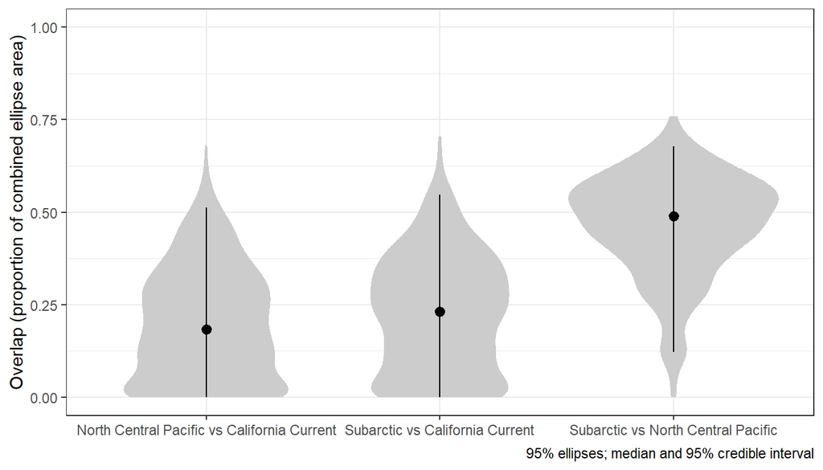

```r
g <- bind_rows(lapply(names(bayes_ov), function(nm) {
  b <- bayes_ov[[nm]]
  data.frame(pair = nm, prop = b$overlap / (b$area1 + b$area2 - b$overlap))
})) %>%
  ggplot(aes(pair, prop)) + geom_violin(fill = "grey80", colour = NA) +
  stat_summary(fun.data = function(x) data.frame(y = median(x), ymin = quantile(x, .025),
                                                 ymax = quantile(x, .975))) +
  coord_cartesian(ylim = c(0, 1)) + theme_bw() +
  labs(x = NULL, y = "Overlap (proportion of combined ellipse area)",
       caption = paste0(SIBER_P * 100, "% ellipses; median and 95% credible interval"))
g
```

```r
ggsave(file.path(FIG, "B_SIBER_overlap.pdf"), g, width = 7, height = 4)
```

**Reading the two approaches together.** Use SEAc / SEA_B (SIBER) to report niche width, and nicheROVER’s directional probabilities as the main overlap result, with SIBER’s area overlap as a check. They should agree on which pairs overlap most, even though the values differ. With only a handful of seals in the smallest strategy, its ellipse and every overlap involving it are uncertain; report the credible intervals.

## 5.6 Sensitivity of the isotopic results

- **One trip per seal** — removes repeated individuals.
- **High-confidence seals only** — bootstrap co-assignment ≥ `LOW_CONFIDENCE`.
- **Year-centred isotopes** — removes year-to-year baseline shifts. Note that this also removes any real difference between strategies that happen to be concentrated in particular years.

```r
iso_c <- dat %>% group_by(ProcedureYear) %>%
  mutate(across(all_of(ISO), ~ .x - mean(.x))) %>% ungroup() %>% as.data.frame()
subsets <- list(`All trips` = dat,
                `One trip per seal` = dat[one, ],
                `High-confidence seals` = dat[dat$coassign >= LOW_CONFIDENCE, ],
                `Year-centred isotopes` = iso_c)

summ_subset <- function(d, nsamples = 5000) {
  d$strategy <- droplevels(d$strategy)
  if (min(table(d$strategy)) < 4) return(NULL)
  nbx <- iso_niche(d, nsamples)
  ov  <- apply(nbx$overlap, c(1:2, 4), mean)[, , 1] * 100
  set.seed(SEED)
  tests <- sapply(ISO, function(v) fl_test(d, v, covars = "ProcedureYear", B = 1999)$p_perm)
  list(n = table(d$strategy),
       SEAb_median = round(apply(nbx$seab, 2, median), 3),
       overlap95 = round(ov, 1),
       p_strategy_given_year = signif(tests, 3))
}
sens_iso <- lapply(subsets, summ_subset)
sens_iso
```

```
## $`All trips`
## $`All trips`$n
##
##             Subarctic North Central Pacific    California Current
##                    48                    39                     6
##
## $`All trips`$SEAb_median
##             Subarctic North Central Pacific    California Current
##                 0.353                 0.260                 0.269
##
## $`All trips`$overlap95
##                        Species B
## Species A               Subarctic North Central Pacific California Current
##   Subarctic                    NA                  79.3               42.4
##   North Central Pacific      90.7                    NA               38.6
##   California Current         45.6                  23.0                 NA
##
## $`All trips`$p_strategy_given_year
##   d13C   d15N
## 0.0005 0.0015
##
##
## $`One trip per seal`
## $`One trip per seal`$n
##
##             Subarctic North Central Pacific    California Current
##                    45                    36                     6
##
## $`One trip per seal`$SEAb_median
##             Subarctic North Central Pacific    California Current
##                 0.365                 0.262                 0.269
##
## $`One trip per seal`$overlap95
##                        Species B
## Species A               Subarctic North Central Pacific California Current
##   Subarctic                    NA                  77.6               41.8
##   North Central Pacific      89.9                    NA               38.3
##   California Current         47.6                  23.3                 NA
##
## $`One trip per seal`$p_strategy_given_year
```

[output cut: 31 more lines]

```
##
## $`Year-centred isotopes`$SEAb_median
##             Subarctic North Central Pacific    California Current
##                 0.347                 0.266                 0.241
##
## $`Year-centred isotopes`$overlap95
##                        Species B
## Species A               Subarctic North Central Pacific California Current
##   Subarctic                    NA                  81.5               34.1
##   North Central Pacific      91.0                    NA               32.1
##   California Current         47.1                  24.9                 NA
##
## $`Year-centred isotopes`$p_strategy_given_year
##   d13C   d15N
## 0.0005 0.0015
```

# 6 Summary

```r
list(
  dimensions = c(N_DIM = N_DIM, pct_variance = round(pc_tab$cum_pct[N_DIM], 1)),
  strategies = table(dat$strategy),
  stability_jaccard = round(setNames(jac_cl[size_order], lev), 2),
  sensitivity_ARI = sens_tab,
  isotope_tests = iso_tests %>% dplyr::select(response, covariates, p_perm, p_BH),
  isotope_equivalence = tost %>% dplyr::select(isotope, contrast, estimate, equivalent, different),
  niche_size = size_tab %>% dplyr::select(strategy, n, SEAc, SEAb_median),
  overlap_95 = round(ov_mean[, , 1], 1),
  SIBER_size = if (exists("siber_size")) siber_size else "SIBER not run",
  SIBER_overlap = if (exists("siber_ov")) siber_ov else "SIBER not run",
  null_structure = null_struct)
```

```
## $dimensions
##        N_DIM pct_variance
##          4.0         74.5
##
## $strategies
##
##             Subarctic North Central Pacific    California Current
##                    48                    39                     6
##
## $stability_jaccard
##             Subarctic North Central Pacific    California Current
##                  0.97                  0.99                  0.85
##
## $sensitivity_ARI
##                             scenario   ARI
## 1                     Dimensions = 3 1.000
## 2                     Dimensions = 5 1.000
## 3                    Dimensions = 19 1.000
## 4      MFA (blocks weighted equally) 0.975
## 5     Log-transform skewed variables 0.934
## 6  Drop redundant SdDist + NorthCPac 0.959
## 7         Ward without consolidation 0.770
## 8               k-means (100 starts) 1.000
## 9      Without multivariate outliers 0.958
## 10                 One trip per seal 1.000
##
## $isotope_tests
##   response    covariates p_perm   p_BH
## 1     d13C          none 0.0002 0.0004
## 2     d13C ProcedureYear 0.0002 0.0004
## 3     d15N          none 0.0024 0.0026
## 4     d15N ProcedureYear 0.0026 0.0026
##
## $isotope_equivalence
##   isotope                                   contrast   estimate equivalent
## 1    d13C          North Central Pacific - Subarctic 0.07047344       TRUE
## 2    d13C             California Current - Subarctic 0.58689459      FALSE
## 3    d13C California Current - North Central Pacific 0.51642114      FALSE
## 4    d15N          North Central Pacific - Subarctic 0.40266735       TRUE
## 5    d15N             California Current - Subarctic 1.15465210      FALSE
```

[output cut: 28 more lines]

```
## $SIBER_overlap
##                       A                     B ML_prop_of_union
## 1             Subarctic North Central Pacific        0.5849892
## 2             Subarctic    California Current        0.3286509
## 3 North Central Pacific    California Current        0.2595992
##   Bayes_prop_of_union  Bayes_prop_of_A  Bayes_prop_of_B
## 1    0.49 (0.12-0.68) 0.57 (0.19-0.83) 0.76 (0.24-0.96)
## 2    0.23 (0.00-0.55) 0.48 (0.00-0.99) 0.30 (0.00-0.70)
## 3    0.18 (0.00-0.51) 0.49 (0.00-1.00) 0.23 (0.00-0.63)
##
## $null_structure
##   k silhouette null_median   null_95           p
## 1 2  0.3671439   0.2583240 0.3000641 0.001996008
## 2 3  0.4061562   0.2206527 0.2550853 0.001996008
## 3 4  0.4147247   0.2140293 0.2442659 0.001996008
```

```r
saveRDS(dat, file.path(OUT, "PB_strategies.rds"))
```

# 7 Suggested Methods text (update numbers from the output)

*Foraging strategies of post-breeding females were identified from 19 movement, habitat-use and diving variables summarising each trip. Variables were standardised and summarised by principal component analysis; the number of components was chosen by Horn’s parallel analysis (1,000 permutations, 95th percentile). Individuals were clustered on the retained components by Ward’s hierarchical clustering followed by k-means consolidation (HCPC; FactoMineR). Candidate solutions (k = 2–8) were evaluated with the gap statistic (Tibshirani et al. 2001), mean silhouette width, minimum cluster size and stability under a whole-pipeline bootstrap (500 resamples; mean Jaccard, Hennig 2007), and the strength of cluster structure was tested against data simulated from a single multivariate normal distribution (silhouette width, 500 simulations). Solutions with k ≥ 4 only isolated single individuals and were unstable. The gap statistic increased from k = 2 to k = 3 but by less than one standard error, so it did not discriminate between them (the conservative 1-SE rule returns k = 2). We retained k = 3 because it was a nested refinement of k = 2 (separating six individuals from one of the two k = 2 clusters), had the highest silhouette width among admissible solutions, all three groups were stable (Jaccard ≥ 0.85), and the additional group differed from the rest of its parent cluster in variables not used for clustering (trip duration, mass-gain rate; permutation tests). Robustness was assessed by comparing partitions (adjusted Rand index) obtained with ±1 component, multiple factor analysis weighting spatial and diving variables equally, log-transformation of skewed variables, removal of redundant variables and of multivariate outliers, alternative clustering algorithms, and one trip per individual. Stable isotope values (δ¹³C, δ¹⁵N) were not used to define strategies and were analysed independently: differences among strategies were tested with Freedman–Lane permutation tests including year as a covariate, equivalence was assessed with two one-sided tests. Isotopic niche width was estimated as the sample-size-corrected standard ellipse area (SEAc) and its Bayesian estimate (SEA_B; SIBER, Jackson et al. 2011; 2 chains of 20,000 iterations, burn-in 1,000, thinning 10, default priors). Niche overlap was estimated as the directional probability that an individual of one strategy falls within the 95 % niche region of another (nicheROVER, default non-informative prior; Swanson et al. 2015), and, as a check, as the area shared by the Bayesian 95 % ellipses relative to their combined area (SIBER).*